# Basic Regression I

Activity 08

Author

Solutions

## Overview

The focus of Activity 08 will be on data modeling using linear regression. Specifically using simple linear regression — one numerical predictor/explanatory variable. We will also continue to practice our data wrangling and visualization skills.

## Needed Packages

The following loads the packages that are needed for this activity. We assume that you have installed the packages. Also note that we have suppressed the `message`s so the compiled html is less cluttered.

**Make sure to load the necessary packages!!**

```r
# LOAD THE NECESSARY PACKAGES
# CONSIDER SUPPRESSING WARNINGS & MESSAGES
library(tidyverse)
library(skimr)
# for challenge
library(broom)
```

## Tasks

Complete the following series of tasks. Remember to **render early and render often**.

## Task 1

### Import state SAT data

We will be exploring a relatively small dataset, but hopefully one that you find interesting. The dataset contains educational data for each US state. That is, each observations is a US state.

The following variables are in the data set: - `state` := state’s abbreviation - `region` := state’s Census defined regions - `sat_math` := state’s mean SAT mathematics score - `teach_pay` := state’s median teacher pay (thousands of dollars) - `pct_taking` := state’s percentage of seniors/juniors taking the SAT - `division` := state’s Census defined division

Import the `state_sat.csv` file which should be located in your `data/` subdirectory. Store the data as `state_sat`.

```r
# import and store the data
state_sat <- read_csv("data/state_sat.csv")
# inspect data with glimpse()
glimpse(state_sat)
```

```
Rows: 51
Columns: 6
$ state      <chr> "AL", "AK", "AZ", "AR", "CA", "CO", "CT", "DE", "DC", "FL",…
$ region     <chr> "South", "West", "West", "South", "West", "West", "Northeas…
$ sat_math   <dbl> 558, 513, 521, 550, 511, 538, 504, 495, 473, 496, 477, 510,…
$ teach_pay  <dbl> 31.3, 49.6, 32.5, 29.3, 43.1, 35.4, 50.3, 40.5, 43.7, 33.3,…
$ pct_taking <dbl> 8, 47, 28, 6, 45, 30, 79, 66, 50, 48, 63, 54, 15, 14, 57, 5…
$ division   <chr> "East South Central", "Pacific", "Mountain", "West South Ce…
```

## Task 2

### EDA

In this section we will be preforming an **E**xploratory **D**ata **A**nalysis (EDA).

Let’s go a little deeper and use `skim_without_charts()` from the `skimr` package which was introduced in the reading. It is an extremely useful package for preforming a quick EDA! It will provide a nice breakdown of the variables in the data with summary statistics.

```r
# LOAD skimr IN load-pkgs CHUNK: MAY NEED TO INSTALL IT
# skim_without_charts() the data
skim_without_charts(state_sat)
```

Data summary

| Name | state_sat |
| --- | --- |
| Number of rows | 51 |
| Number of columns | 6 |
| _______________________ |  |
| Column type frequency: |  |
| character | 3 |
| numeric | 3 |
| ________________________ |  |
| Group variables | None |

**Variable type: character**

| skim_variable | n_missing | complete_rate | min | max | empty | n_unique | whitespace |
| --- | --- | --- | --- | --- | --- | --- | --- |
| state | 0 | 1 | 2 | 2 | 0 | 51 | 0 |
| region | 0 | 1 | 4 | 9 | 0 | 4 | 0 |
| division | 0 | 1 | 7 | 18 | 0 | 9 | 0 |

**Variable type: numeric**

| skim_variable | n_missing | complete_rate | mean | sd | p0 | p25 | p50 | p75 | p100 |
| --- | --- | --- | --- | --- | --- | --- | --- | --- | --- |
| sat_math | 0 | 1 | 529.27 | 34.83 | 473.0 | 500.00 | 521 | 557.00 | 600.0 |
| teach_pay | 0 | 1 | 35.89 | 6.23 | 26.3 | 31.55 | 35 | 40.05 | 50.3 |
| pct_taking | 0 | 1 | 35.49 | 26.29 | 4.0 | 9.00 | 30 | 61.00 | 80.0 |

Use this output to describe important features of the dataset such as: missingness for variables, number of `region` levels/categories, number of `division` levels/categories, and a quick check of the numeric variables — do the summary statistics imply the data is reasonable.

**There is no missing data.There are 4 unique regions and 9 unique divisions. There are no clear outliers or strange values for the numerical variables. The data appears to be reasonable.**

We will be exploring the relationship between SAT math scores (`sat_math`) and teacher pay (`teach_pay`).

Let’s begin exploring the relationship between `sat_math` and `teach_pay` visually.

I’ve provided a scatterplot below - remove `eval: false` so that it will be included in the output.

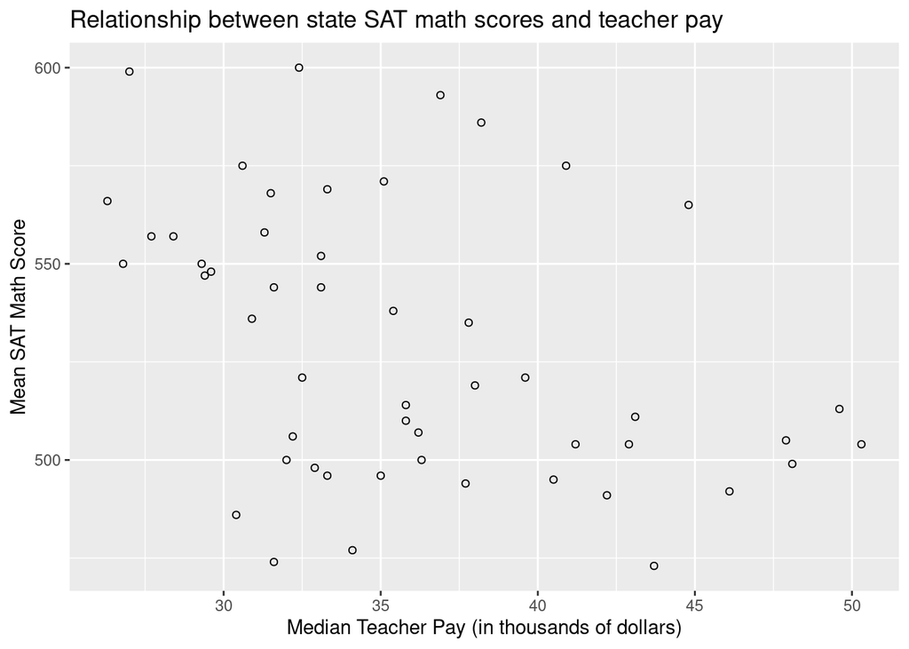

```r
ggplot(state_sat, aes(x = teach_pay, y = sat_math)) +
  geom_point(shape = 1) +
  labs(
    title = "Relationship between state SAT math scores and teacher pay",
    x = "Median Teacher Pay (in thousands of dollars)",
    y = "Mean SAT Math Score"
    )
```

Does there look to be a linear relationship/association between the two variables? Calculate the correlation between these two variables.

```r
# CALCULATE CORRELATION
cor(state_sat$sat_math, state_sat$teach_pay)
```

```
[1] -0.4039747
```

```r
# alternative way
state_sat %>%
  summarise(correlation = cor(sat_math, teach_pay))
```

```
# A tibble: 1 × 1
  correlation
        <dbl>
1      -0.404
```

Given the graph and correlation, describe the relationship/association between these two variables. Does this relationship seem reasonable or expected? Explain.

**Looks like there is a modest negative linear association between a state’s median teacher pay and its mean SAT math score.**

**The relationship does not seem reasonable. More pay is associated with a decrease in math performance. We would expect that if a state typically pays better they would typically get better results (i.e. math scores).**

Copy the graphic above and let’s layer/add on the line of best fit to our graph to help us visualize the relationship. Recall from the book we will want `method = "lm"` and `se = FALSE` for this layer.

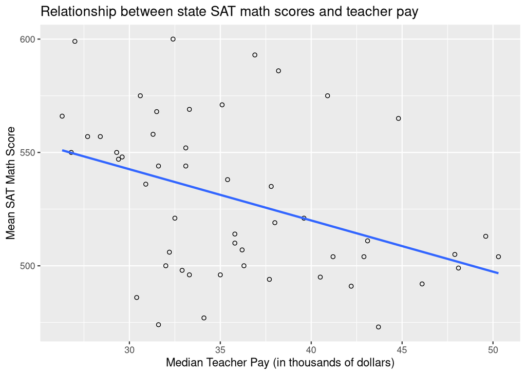

```r
# BUILD GRAPHIC HERE
ggplot(state_sat, aes(x = teach_pay, y = sat_math)) +
  geom_point(shape = 1) +
  labs(
    title = "Relationship between state SAT math scores and teacher pay",
    x = "Median Teacher Pay (in thousands of dollars)",
    y = "Mean SAT Math Score"
    ) +
  geom_smooth(method = "lm", se = FALSE)
```

## Task 3

### Fit a model

In the last graphic we fit a simple linear regression/model to the data. We want to calculate the equation for this line and interpret its values in the context of our problem. Use `lm()` to calculate the model fit and store the result in `math_pay_model`.

```r
# fit & store the model sat_math ~ teach_pay
#| label: fit-model
math_pay_model <- lm(sat_math ~ teach_pay, data = state_sat)
```

Below the following R chunk is an equation for the line of best fit, but it is missing the estimated intercept ($b_0$) and slope ($b_1$). We can get these estimates by running/printing `math_pay_model`. We can also get them as part of a more comprehensive print out that summarizes the fitted model. The code for both are provided below.

```r
## REMOVE eval=FALSE IN R CHUNK OPTIONS
## ASSUMES YOU HAVE CREATED math_pay_model
# just estimated coefficients
math_pay_model
```

```
Call:
lm(formula = sat_math ~ teach_pay, data = state_sat)

Coefficients:
(Intercept)    teach_pay
     610.40        -2.26
```

```r
# estimated coefficients with std output
summary(math_pay_model)$coefficients
```

```
              Estimate Std. Error   t value     Pr(>|t|)
(Intercept) 610.395612  26.626085 22.924723 7.578726e-28
teach_pay    -2.260258   0.731169 -3.091294 3.283602e-03
```

- Intercept: **For a state with median teacher pay of $0 we would EXPECT its mean SAT math score to be about 610.**
- Slope: **For each additional $1,000 in median teacher pay a state’s mean SAT math score DECREASES, on average, by about 2.26 points.**

## Task 4

### Fitted values & residuals

Let’s take our model and calculate fitted/predicted values for each state’s mean SAT math score and compare them to their actual/observed values — residuals.

To do this:

1. Begin with `state_sat` then
2. keep the variables `state`, `teach_pay`, and `sat_math`, then
3. create/calculate two new variables called `sat_math_hat` and `residual` using `math_pay_model` with the functions `fitted()` and `residuals()` respectively, then
4. keep only the following observations/states: South Dakota (`"SD"`), Illinois (`"IL"`), and Florida (`"FL"`). Feel free to add another state of your choice.

```r
# calculate fitted values and residuals
state_sat %>%
  select(state, teach_pay, sat_math) %>%
  mutate(
    sat_math_hat = fitted(math_pay_model),
    residual = residuals(math_pay_model)
  ) %>%
  filter(state %in% c("SD", "IL", "FL"))
```

```
# A tibble: 3 × 5
  state teach_pay sat_math sat_math_hat residual
  <chr>     <dbl>    <dbl>        <dbl>    <dbl>
1 FL         33.3      496         535.    -39.1
2 IL         40.9      575         518.     57.0
3 SD         26.3      566         551.     15.0
```

Identify if the model over- or under-estimates the mean SAT math score for each state. Which of the three states does it estimate best? Worst? Does a negative residual correspond with an over- or under-estimate by the model?

**Overestimates for FL and underestimates for IL and SD. It does the best at estimating SD’s mean SAT math score a worst for IL. Negative residuals correspond to overestimation by the model.**

## Task 5

### Prediction

Suppose we told you that a mythical 52<sup>nd</sup> state existed and it paid its teacher’s a median salary of $47.5 thousand. Using the regression model, what would you estimate it’s mean SAT math score to be? Answer should be in a complete sentence.

```r
# estimate using the equation above
610.4 - 2.26 * 47.5
```

```
[1] 503.05
```